# Part II - Ford GoBike System Data

## by Maryam Alablani

## Investigation Overview

> In this investigation, I wanted to look at the trips data and characteristics, and it focused on the duration, the user's age, the user's type, and the user's gender.

## Dataset Overview

> The database consists of 183412 Ford GoBike and contains 16 features representing different data such as (age, gender, user type, duration, and others).

## (Visualization 1)

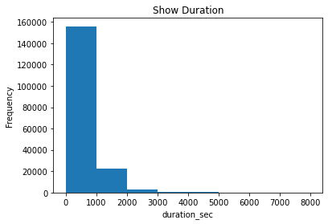

## (Visualization 2)

> Here is the distribution of gender of the members and is divided into three categories: male, female, and others. It shows that the highest percentage is male, which is 74.60%, followed by female, which is 23.32%, and the lowest is others, which is 2.09%.

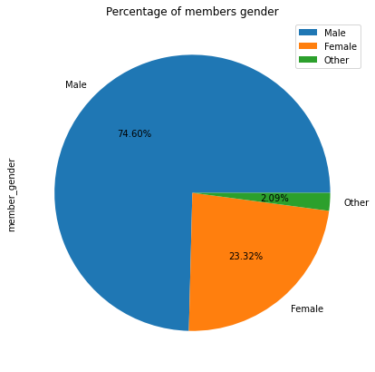

## (Visualization 3)

> Here is the distribution of users' age, ranging from 0 to 100, it was found that most of the users' age are between 0 and 50 and the rest are between 50 and 100.

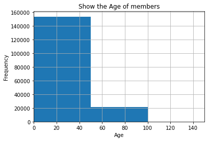

## (Visualization 4)

Here is the distribution of the type of the user is shown in relation to his gender and the number of his frequency, and it turns out that the most frequent in subscriber is in males, then followed by females than in subscriber.

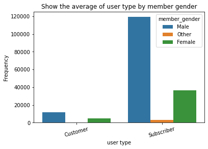